# Basic illustration of the ICC approach

Mike

2/19/2021

```r
source(here::here("helper/common.R"))
```

```
## here() starts at /Users/martincz/GitHub/peekbank-method
```

Here’s the distribution of average looking across all trials.

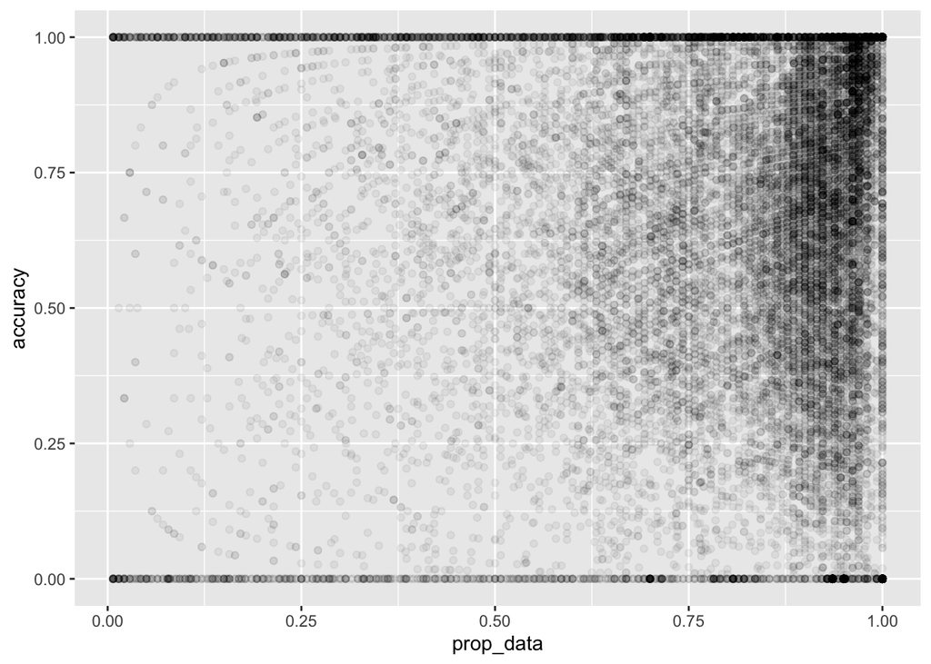

```r
d_summary <- d_trial |>
  group_by(dataset_name, trial_id, dataset_id, subject_id, administration_id,
           target_label) |>
  summarise(accuracy = mean(correct[t_norm > 500], na.rm=TRUE),
            prop_data = mean(!is.na(correct[t_norm > 500]))) |>
  filter(!is.na(accuracy))

ggplot(d_summary, aes(x = prop_data, y = accuracy)) +
  geom_point(alpha = .05)
```

We’re going to use ICCs to measure reliability, using McGraw & Wong (1996). It seems like we want two-way random effects, no interaction (subjects and items are meaningful). This is type “2A.” We want average agreement across units.

One big decision is whether to look across stimulus items, rather than across kids. Across stimulus items returns *much* higher values. This is in part because we typically have more kids than items, and kids are sort of like “raters.”

## Swingley and Aslin

Let’s look at one dataset. Here are the stimulus and administration ICCs for Swingley & Aslin (2002).

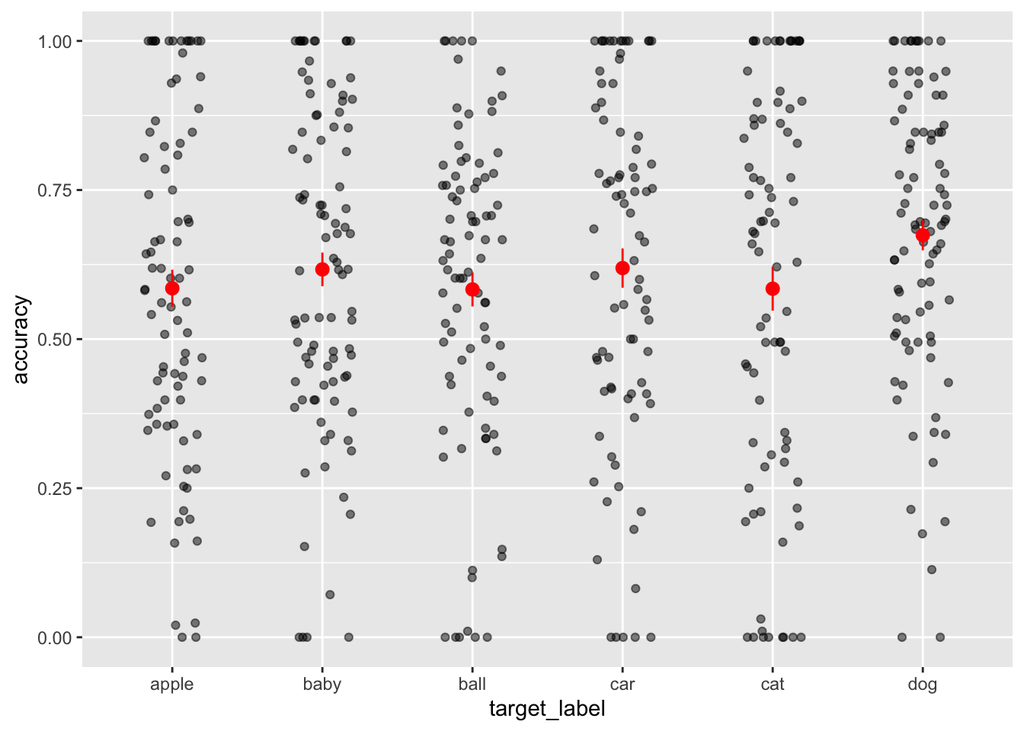

```r
sa <- d_summary |>
  filter(dataset_name == "swingley_aslin_2002")

sa_cleaned <- filter(sa,
                     !(target_label %in% c("bird","duck","shoe","truck")))

ggplot(sa_cleaned,
       aes(x = target_label, y = accuracy)) +
  geom_jitter(alpha = .5, width = .2) +
  stat_summary(col = "red")
```

Now check ICCs.

```r
# disaggregated
get_icc(sa, object = "stimulus")
```

```
## [1] 0.4470579
```

```r
get_icc(sa, object = "administration")
```

```
## [1] 0.1861159
```

```r
# disaggregated and cleaned
get_icc(sa_cleaned, object = "stimulus")
```

```
## [1] 0.1913162
```

```r
get_icc(sa_cleaned, object = "administration")
```

```
## [1] 0.1946951
```

```r
# aggregated
sa_agg <- sa |>
  group_by(target_label, administration_id, trial_id) |>
  summarise(accuracy = mean(accuracy))
get_icc(sa_agg, object = "stimulus")
```

```
## [1] 0.4470579
```

```r
get_icc(sa_agg, object = "administration")
```

```
## [1] 0.1861159
```

```r
dim_icc(sa,
        model = "2A",
        type = "agreement",
        unit = "average",
        object = administration_id,
        rater = target_label,
        trial = trial_id,
        score = accuracy,
        bootstrap = 1000)
```

```
##
## Intraclass Correlation Coefficient
## (Model 2A, Agreement, Average of 10 Raters)
##
##                   Estimate   2.5 %   97.5 %
## Intra-Rater ICC      0.037   0.015    0.123
## Inter-Rater ICC      0.186   0.000    0.406
```

```r
dim_icc(sa,
        model = "2A",
        type = "agreement",
        unit = "average",
        object = target_label,
        rater = administration_id,
        trial = trial_id,
        score = accuracy,
        bootstrap = 1000)
```

[output not shown]

Last question: inter vs. intra-rater reliability.

```r
dim_icc(sa,
        model = "2A",
        type = "agreement",
        unit = "average",
        object = administration_id,
        rater = target_label,
        trial = trial_id,
        score = accuracy,
        bootstrap = 0)
```

```
##
## Intraclass Correlation Coefficient
## (Model 2A, Agreement, Average of 10 Raters)
##
##                   Estimate   2.5 %   97.5 %
## Intra-Rater ICC      0.037
## Inter-Rater ICC      0.186
```

```r
dim_icc(sa_agg,
        model = "2A",
        type = "agreement",
        unit = "average",
        object = administration_id,
        rater = target_label,
        score = accuracy,
        bootstrap = 0)
```

```
##
## Intraclass Correlation Coefficient
## (Model 2A, Agreement, Average of 10 Raters)
##
##                   Estimate   2.5 %   97.5 %
## Intra-Rater ICC      0.001
## Inter-Rater ICC      0.000
```

We’re not actually sure how the **intra**-rater reliabilities are computed when you have only one observation per rater (shouldn’t they be zero then?). But we’re pretty clear we want the **inter**-rater reliabilities.

## Across datasets

Note that we need to remove NaNs to make the ICCs work.

```r
iccs <- d_summary |>
  group_by(dataset_name) |>
  nest() |>
  mutate(icc_stimulus_acc = unlist(map(data, ~get_icc(.x, object = "stimulus"))),
         icc_admin_acc = unlist(map(data, ~get_icc(.x, object = "administration")))) |>
  select(-data) |>
  unnest(cols = c())

knitr::kable(iccs, digits = 2)
```

| dataset_name | icc_stimulus_acc | icc_admin_acc |
| --- | --- | --- |
| adams_marchman_2018 | 0.81 | 0.40 |
| attword_processed | 0.94 | 0.35 |
| fmw_2013 | 0.77 | 0.54 |
| frank_tablet_2016 | 0.81 | 0.64 |
| garrison_bergelson_2020 | 0.70 | 0.82 |
| mahr_coartic | 0.67 | 0.41 |
| perry_cowpig | 0.47 | 0.35 |
| pomper_saffran_2016 | 0.86 | 0.77 |
| pomper_salientme | 0.80 | 0.46 |
| potter_canine | 0.58 | 0.57 |
| potter_remix | 0.40 | 0.29 |
| reflook_socword | 0.92 | 0.47 |
| reflook_v4 | 0.73 | 0.58 |
| ronfard_2021 | 0.38 | 0.51 |
| swingley_aslin_2002 | 0.45 | 0.19 |

```r
save(iccs, file= here("cached_intermediates","2_iccs_accuracy.Rds"))
```